# Contraceptive Method Predictor Report

Christopher Alexander, Yik Hong Chan, Abhiket Gaurav, Valli A updated: 2021-12-11

# Summary

Here we attempt to build a classification model using the SVC classifier algorithm which can help predict the use/or no use contraceptives by women based on their demographic and socio-economic characteristics. The target which was originally of 3 classes has been modified to 2 classes with target `1` defining usage of contraceptive (including short term and long term) and `0` defining no usage of contraceptive for simplicity and practical reasons.

The overall accuracy of the model is ~ 74% and the area under the curve (AUC) is of 78%.Given that the data-set was limited this seems to be a decent score. However the model still has a few false predictions for the non usage of contraceptive. These cases where false positives, that is predicting the usage of contraceptive when in fact the person does not use contraceptives. These kind of predictions give wrong insights of contraceptive usage, thus we feel further work to improve model prediction is needed before we could put this model in the real world.

Demographic Details of the location in use:

The data used in our project is a subset of 1987 National Indonesia Contraceptive Prevalence Survey. The samples are married women who were either not pregnant or do not know if they were at the time of interview.

Inclusion of Wife’s religion Feature:

We have not dropped the wife’s religion feature while building our model to predict owing to the following reasons:

1. The country of data collection is Indonesia, which has 90% of the population following one particular religion. Because our project includes analysis of a population based on socio-economic and demographic parameters, not including religion in this data-set would render it incomplete and could also lead to skewed analysis of data. Therefore we believe , purely in the interest of objectivity that not including religion as a feature based on some non objective reason would be unscientifically unethical and irresponsible.
2. Also, our data has only 9 features and dropping one of them would not help us get proper results.
3. The difference in the training and the test scores is not much, hence we can say that our model is not over-fitting and hence, mathematically also, we see no need to drop the feature

Disclaimer*

Inclusion of the wife’s religion feature is intended purely for objective scientific analysis.

# Introduction

In this project we are trying to answer the question: given the demographic and socio-economic status of a married woman can we predict the use of contraceptive or not ? Answering this question is important because of the adverse side effects contraceptives can have on a woman’s health. Furthermore, it also gives us an understanding of the factors that could have contributed to the reasons behind why the contraceptive market is such a big industry in the health care sector right now. Here we approach this problem by using machine learning algorithm to predict whether a married woman prefers to use contraceptive or not given her demographic and socio-economic status.

Disclaimer:

The study is limited to the data collected back in 1987, in Indonesia. The whole analysis and model is based on this data-set and in no way, should be used in general sense. This study is just for academic purposes and should be used with caution when applying to “married-women in general” and to “different geographies”. The data is dated, and the global scenarios has changed a lot since then.Hence, no conclusive remarks should be made.

# Data

This data-set is a subset of the 1987 National Indonesia Contraceptive Prevalence Survey (Lim, Loh, and Shih 2000). It was sourced from the UCI Machine Learning Repository (Dua and Graff 2017) and can be found [here](https://archive.ics.uci.edu/ml/datasets/Contraceptive+Method+Choice). The samples are of married women who were either not pregnant or do not know if they were at the time of interview. Each row in the data set represents the sample taken from women, including their demographic information and their socio-economic status.

# Exploratory Data Analysis (EDA)

## Summary of the training dataset

First, it is important to identify and understand the attributes of the data-set. Exploratory data analysis was performed on the training data-set and was found to have no missing values. The attributes of the training data-set are outlined below

| Column name | Description | Type | Values |
| --- | --- | --- | --- |
| Wife age | Wife’s age | Numerical | any positive values |
| Wife education | Wife’s education | Categorical | 1=low, 2, 3, 4=high |
| Husband education | Husband’s education | Categorical | 1=low, 2, 3, 4=high |
| Number of children ever born | Number of children ever born | Numerical | any positive values |
| Wife religion | Wife’s religion | Binary | 0=Non-Islam, 1=Islam |
| Wife now working? | Is wife working or not | Binary | 0=Yes, 1=No |
| Husband occupation | Husband’s occupation | Categorical | 1, 2, 3, 4 |
| Standard-of-living index | Standard-of-living Index | Categorical | 1=low, 2, 3, 4=high |
| Media Exposure | Media exposure | Binary | 0=Good, 1=Not good |
| Contraceptive method used | Contraceptive method used (Class Attribute) | Categorical | 1=No-use, 2=Long-term, 3=Short-term |

```python
import pandas as pd
train_df = pd.read_csv(
    "../data/processed/train.csv"
)
train_df.info()
```

```
## <class 'pandas.core.frame.DataFrame'>
## RangeIndex: 1031 entries, 0 to 1030
## Data columns (total 10 columns):
##  #   Column                        Non-Null Count  Dtype
## ---  ------                        --------------  -----
##  0   Wife_age                      1031 non-null   int64
##  1   Wife_education                1031 non-null   int64
##  2   Husband_education             1031 non-null   int64
##  3   Number_of_children_ever_born  1031 non-null   int64
##  4   Wife_religion                 1031 non-null   int64
##  5   Wife_now_working?             1031 non-null   int64
##  6   Husband_occupation            1031 non-null   int64
##  7   Standard_of_living_index      1031 non-null   int64
##  8   Media_exposure                1031 non-null   int64
##  9   Contraceptive_method_used     1031 non-null   int64
## dtypes: int64(10)
## memory usage: 80.7 KB
```

## Distribution of target class

From the histogram @ref(fig:histTarget) it can be observed that there are three classes - with 1 (“No-use”), 2 (“Long-term use”), followed by 3 (“Short-term use”). We have combined 2 and 3 as “use” case and have left 1 as it is (“no-use” case). With this modification we are trying to predict the “use vs no use” of contraceptives.

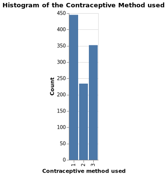

## Histogram of all numerical features

From the distributions in the histogram @ref(fig:histNum), it can be observed that the data is skewed to the right. This can be attributed to significantly higher numbers of married woman who are between 28 to 38 years old than those with ages higher than 38 years, and that most of the woman have two to three kids on average.

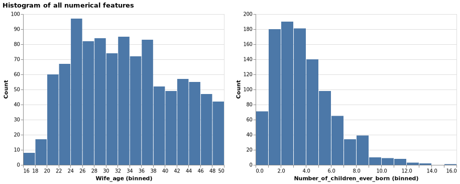

## Histogram of all non-numerical features

From the histogram @ref(fig:countCat), it can be observed that a majority of the responses / observations in the survey are from women having high levels of education, religious beliefs, with educated partners and with a high standard of living.

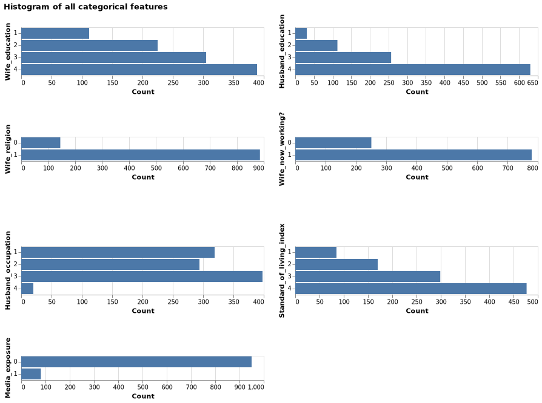

## Relation betweeen target and non-numerical features

From the figure @ref(fig:countCatByTarget), it can be observed that most of the observations of target class 1 (no contraception) rest on certain categorical values. However, as we had earlier pointed out the imbalance in the distribution of class values, we cannot imply correlation.

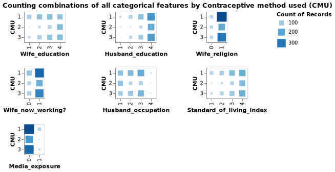

# Pre-Processing & Model Selection

## Data Pre-Processing

Based on the EDA (Exploratory Data Analysis) performed earlier and variable descriptions, it can be inferred that there are no missing values. However, the variables were of different data types. In order to perform operations on data, we need to ensure consistency of data types. The following table shows different variables in the data-set and the respective transformation performed on each of them.

| Data Type | Variable | Transformation performed | Technique used |
| --- | --- | --- | --- |
| Numerical | Wife’s age, Number of children ever born | Scaling | Standard Scaling |
| Ordinal | Wife’s education, Husband Education, | Encoding | Ordinal Encoding |
| Ordinal | Husband’s Occupation,Standard of living Index | Encoding | Ordinal Encoding |
| Binary | Wife’s religion, Wife working Media Exposure | None | Pass through |

For simplicity and better model performance. We have combined `2 = Long-term`, `3 = Short-term` into one class and it was given a value of `1`. The label `1 = No-use` was given a value of `0`, because our aim is to predict the use(long or short)/ no use of contraceptives .

Our target distribution now have * `0 = No-use` : **445** observations, * `1 = use` : **586** observations.

# Finding the best Model:

With this data, our problem statement now turns into binary classification problem. We have tried the following predictive models:

1. Decision Tree
2. kNN
3. Logistic Regression
4. RBF SVC

## Results of Cross Validation

| X | decision.tree | kNN | Logistic.Regression | RBF.SVM |
| --- | --- | --- | --- | --- |
| fit_time | 0.0119304 | 0.0125099 | 0.0259015 | 0.0421597 |
| score_time | 0.0069579 | 0.0134420 | 0.0076053 | 0.0162925 |
| test_score | 0.6313916 | 0.6527930 | 0.6595563 | 0.6944796 |
| train_score | 0.9856934 | 0.7725510 | 0.6808932 | 0.7485466 |

Cross Validation Result (Score for Accuracy)

## Hyper-Parameter Optimization

Given the performance of RBF SVC was the best, it was chosen for hyper-parameter tuning. The results of the top 5 models are shown in @ref(tab:hyperparam).

It can be observed that the best parameters are: `C = 10.0`, `gamma = 0.01`.

| X | X1 | X2 | X3 | X4 | X5 |
| --- | --- | --- | --- | --- | --- |
| mean_test_score | 0.7012710 | 0.6973969 | 0.6964214 | 0.6954833 | 0.6935275 |
| param_svc__gamma | 0.0100000 | 0.0010000 | 0.0100000 | 0.0100000 | 0.1000000 |
| param_svc__C | 10.0000000 | 1000.0000000 | 1000.0000000 | 100.0000000 | 10.0000000 |
| param_svc__class_weight | NA | NA | NA | NA | NA |
| mean_fit_time | 0.2058732 | 0.1529772 | 0.4046357 | 0.1714467 | 0.1902466 |

Hyperparameter Selection

# Model Testing

After finding out the best parameters by optimizing the accuracy score, we tried the model on the test data set.

## Confusion Matrix:

A study of the confusion matrix will provide an understanding into the model’s predictive power from the figure @ref(fig:confusionmat):

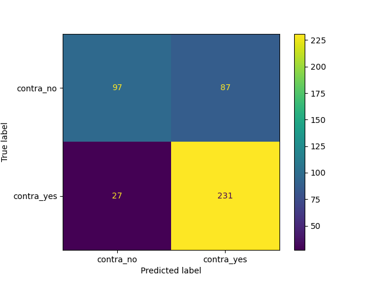

We have considered the use of contraceptive method as positive class.By looking at the confusion matrix, it can be observed that the model is predicting well on the total number of `True positives` i.e 231 which are the ones that the model predicted correctly to be using contraceptive method.and `True Negatives` i.e 97 which denotes correctly for not using contraceptive method. However, there are some false +ve and -ve observed as well.

`False positives` are indicated when we affirmatively predict the usage of contraceptives when in fact, the person does not use contraceptives i.e in our matrix 87 .and `False Negatives` indicated when we incorrectly predict the person is not using, when they are actually using contraceptives.

## Scoring Metric:

The recall, precision and the f1-score were observed while considering each class to be the positive class. The recall value of **0.90** indicates a good true positive rate (TPR) for the `1` class while the **0.53** indicates the TPR of the `0` class. These cumulative scores can be found in `macro avg` and `weighted avg` in the table @ref(tab:scoringmet).

| X | precision | recall | f1.score | support |
| --- | --- | --- | --- | --- |
| contra_no | 0.7822581 | 0.5271739 | 0.6298701 | 184 |
| contra_yes | 0.7264151 | 0.8953488 | 0.8020833 | 258 |
| accuracy | NA | NA | 0.7420814 | NA |
| macro avg | 0.7543366 | 0.7112614 | 0.7159767 | 442 |
| weighted avg | 0.7496619 | 0.7420814 | 0.7303928 | 442 |

Scoring Metrics

## Precision-Recall Curve:

The precision and recall trade-off of our model could be observed by plotting the PR curve with the mean Average Precision score. A good enough AP score of 0.79 could be observed from the figure @ref(fig:precrec).

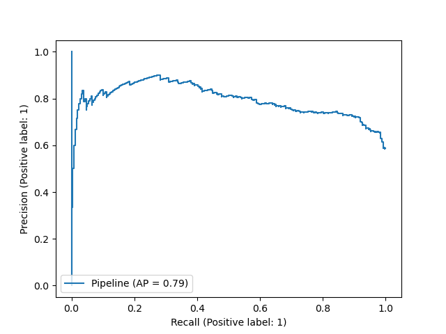

## ROC Curve

As mentioned above, the curves were plotted at a threshold of 0.5. In order to obtain an overall score for our model, the Area under the curve was observed which resulted in a decent score of 78% from the figure @ref(fig:roccurve).

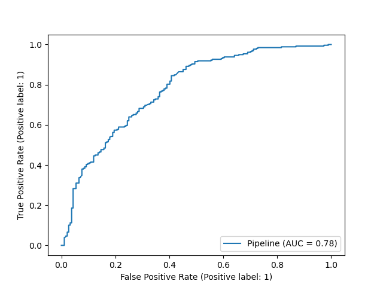

## Feature Importance

We have predicted the co-efficients/ weights of each features and found that the features Number_of_children_ever_born, wife_age, wife_education are considered to be top three features of importance.

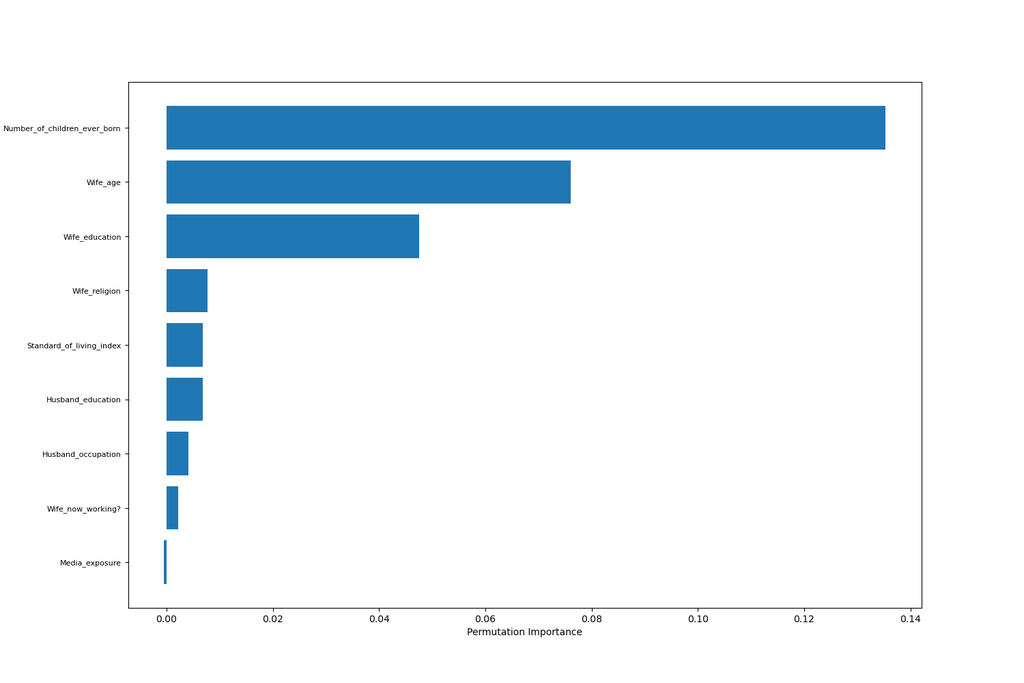

# Final Conclusion

The intent of the process was to predict the use of contraceptives in married woman based on socio-economic and education levels. In the process, 4 different models were tried. It can be observed from the above parameters that the chosen model is indeed performing well(given the size of the data-set) with an accuracy of 74% , `recall` of 90%, `precision` of 73% , `f1_score` of 80% and `AUC` 78%. The precision indicates, that out of all predicted positives,how many are actually positive, ie. out of 100 predicted positive samples, 73 were actually using the contraceptives. Recall indicates, out of total positives how many are predicted positive A high recall shows that our model could identify most of them correctly. These results are in line with the validation scores outlined previously. The high `recall value` of 90% also indicates that `False Negatives` are very low and an appreciable f1_score of 0.8.

However, it could be also be observed that there are indeed cases where the model is not predicting correctly, and hence there is scope for improvement before the model is deployed in a real world scenario.

# Acknowledgment

This data-set is a subset of the 1987 National Indonesia Contraceptive Prevalence Survey (Lim, Loh, and Shih 2000). It was sourced from the UCI Machine Learning Repository (Dua and Graff 2017).

The Python programming languages (Van Rossum and Drake Jr 1995) and the following Python packages were used to perform the analysis: altair (VanderPlas et al. 2018), docopt (de Jonge 2018), matplotlib (Hunter 2007), numpy (Harris et al. 2020), pandas (McKinney et al. 2010), sckit-learn (Pedregosa et al. 2011). The code used to perform the analysis and create this report can be found [here](https://github.com/UBC-MDS/contraceptive_method_predictor/tree/main/src).

# References

de Jonge, Edwin. 2018. *Docopt: Command-Line Interface Specification Language*. https://CRAN.R-project.org/package=docopt.

Dua, Dheeru, and Casey Graff. 2017. “UCI Machine Learning Repository.” University of California, Irvine, School of Information; Computer Sciences. http://archive.ics.uci.edu/ml.

Harris, Charles R., K. Jarrod Millman, Stéfan J van der Walt, Ralf Gommers, Pauli Virtanen, David Cournapeau, Eric Wieser, et al. 2020. “Array Programming with NumPy.” *Nature* 585: 357–62. https://doi.org/10.1038/s41586-020-2649-2.

Hunter, John D. 2007. “Matplotlib: A 2d Graphics Environment.” *Computing in Science & Engineering* 9 (3): 90–95.

Lim, Tjen-Sien, Wei-Yin Loh, and Yu-Shan Shih. 2000. “A Comparison of Prediction Accuracy, Complexity, and Training Time of Thirty-Three Old and New Classification Algorithms.” *Machine Learning* 40 (3): 203–28.

McKinney, Wes et al. 2010. “Data Structures for Statistical Computing in Python.” In *Proceedings of the 9th Python in Science Conference*, 445:51–56. Austin, TX.

Pedregosa, Fabian, Gaël Varoquaux, Alexandre Gramfort, Vincent Michel, Bertrand Thirion, Olivier Grisel, Mathieu Blondel, et al. 2011. “Scikit-Learn: Machine Learning in Python.” *Journal of Machine Learning Research* 12 (Oct): 2825–30.

Van Rossum, Guido, and Fred L Drake Jr. 1995. *Python Tutorial*. Centrum voor Wiskunde en Informatica Amsterdam, The Netherlands.

VanderPlas, Jacob, Brian Granger, Jeffrey Heer, Dominik Moritz, Kanit Wongsuphasawat, Arvind Satyanarayan, Eitan Lees, Ilia Timofeev, Ben Welsh, and Scott Sievert. 2018. “Altair: Interactive Statistical Visualizations for Python.” *Journal of Open Source Software* 3 (32): 1057.